# Gráficos alternativos para grandes conjuntos de dados

Recentemente, ao tentar fazer gráficos exploratórios de um grande conjunto de dados (~300 mil observações), fiz uma rápida busca na internet e achei alternativas interessantes aos histogramas de frequência e densidade e também aos famosos boxplots. Abaixo, apresento exemplos do que encontrei.

Nesse roteiro, todos os gráficos utilizarão como base o pacote `ggplot2`, e algumas manipulações dos dados com o pacote `dplyr`. Ah, e eu também uso o pacote `cowplot`para tornar os plots do ggplot estéticamente melhores.

```r
library(ggplot2)
library(dplyr)
library(cowplot)
library(lvplot)
```

Vamos usar o conjunto de dados `ontime` do pacote `lvplot`, que detalha o desempenho no horário dos vôos nacionais dos EUA em janeiro de 2015, veja uma amostra dos dados na Tabela @ref(tab:dados).

Algumas linhas da tabela de dados.

| FlightDate | UniqueCarrier | FlightNum | DepTime | ArrTime | TaxiOut | TaxiIn |
| --- | --- | --- | --- | --- | --- | --- |
| 2015-01-01 | AA | 1 | 0855 | 1237 | 17 | 7 |
| 2015-01-02 | AA | 1 | 0850 | 1211 | 15 | 9 |
| 2015-01-03 | AA | 1 | 0853 | 1151 | 15 | 13 |
| 2015-01-04 | AA | 1 | 0853 | 1218 | 14 | 19 |
| 2015-01-05 | AA | 1 | 0853 | 1222 | 27 | 24 |
| 2015-01-06 | AA | 1 | 0856 | 1300 | 85 | 4 |
| 2015-01-07 | AA | 1 | 0859 | 1221 | 29 | 12 |
| 2015-01-08 | AA | 1 | 0856 | 1158 | 26 | 3 |
| 2015-01-09 | AA | 1 | 0901 | 1241 | 43 | 4 |
| 2015-01-10 | AA | 1 | 0903 | 1235 | 37 | 10 |

Comecemos com os histogramas!

# Histogramas

O primeiro gráfico para comparar a distribuição de variáveis contínuas é o histograma de frequência (Figura @ref(fig:freq)) ou densidade (Figura @ref(fig:densi)). Muitas vezes o que queremos fazer é comparar os histogramas em função de algum variável categórica, como no exemplo abaixo, onde criamos os histogramas da variável `TaxiOut`[^1] em funcão das companhias aéreas (`UniqueCarrier`).

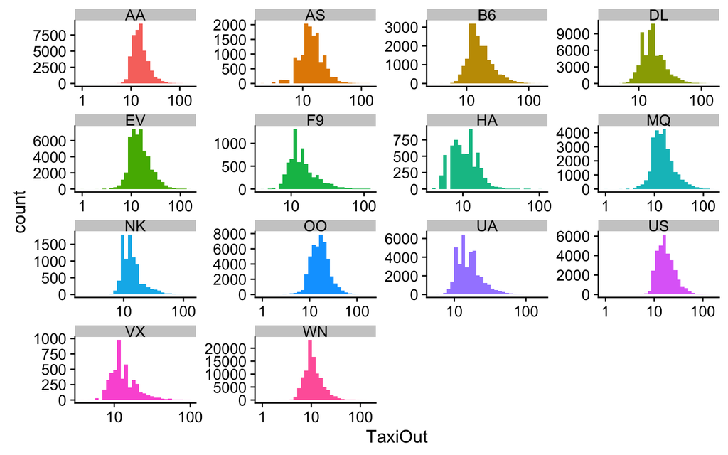

Histograma de frequência por companhia aérea.

```r
hi <- ggplot(ontime, aes(x = TaxiOut, fill = UniqueCarrier)) +
  facet_wrap(~UniqueCarrier, scales = "free") + #deixei as escalas livres
  scale_x_log10() +
  theme(legend.position = "none")
hi + geom_histogram()
```

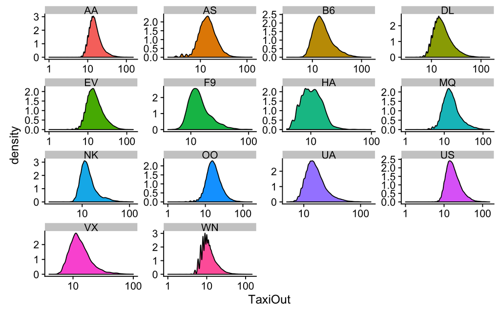

Histograma de densidade por companhia aérea.

```r
hi + geom_density()
```

Como os histogramas separados em cada plot, às vezes fica difícil compará-los para entender possíveis diferenças entre os grupos analisados.

# Alternativa 1: Ridgeline plots

Uma alternativa ao histograma de densidade são os ridgeline plots do pacote `ggridges` que são gráficos parcialmente sobrepostos criando a impressão de uma cadeia de montanhas (Figura @ref(fig:ridge)). São gráficos particularmente bons para visualizar as mudanças na distribuição no tempo e espaço, pois permite uma comparação visualmente mais fácil entre os grupos. Não deixe de olhar a vinheta do pacote para exemplos de customização.

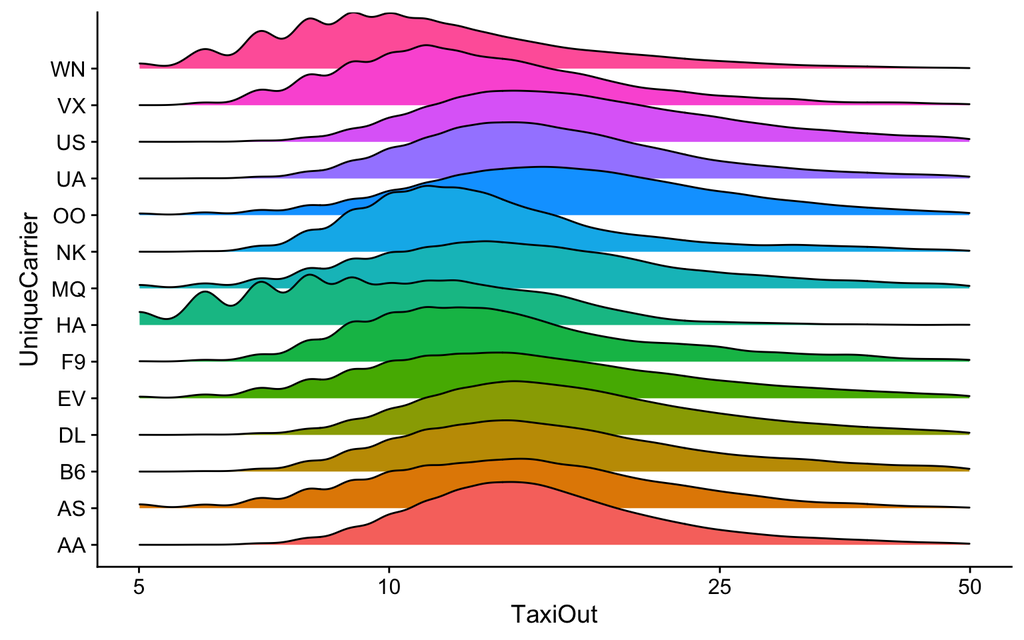

Ridges plots formando uma cadeia de montanhas das densidades das distribuições dos dados para cada companhia aérea.

```r
library(ggridges)

rplot <- ontime %>%
  mutate(group = reorder(UniqueCarrier, TaxiOut, median)) %>%
  ggplot(aes(x = TaxiOut, y = UniqueCarrier, fill=UniqueCarrier)) +
  scale_x_log10(limits=c(5,50), breaks= c(5,10,25,50)) +
  theme(legend.position = "none")

rplot +  geom_density_ridges()
```

A altura de cada densidade pode ser ajustada para haver menos sobreposição:

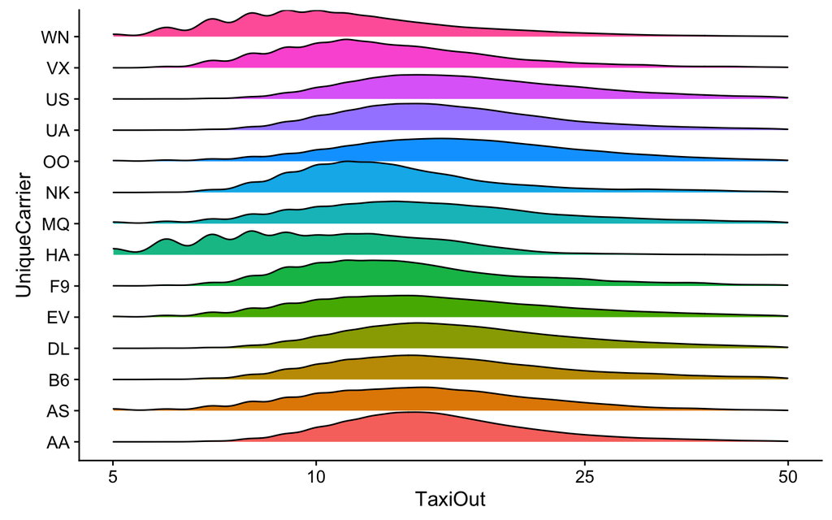

Uma alternativa caso não queiramos as montanhas sobrepostas.

```r
rplot + geom_density_ridges(scale=1)
```

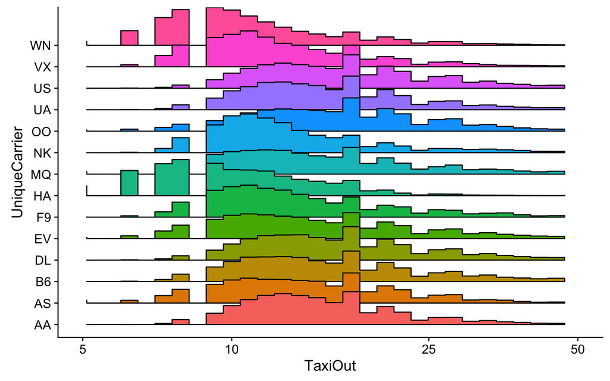

Usando frequência ao invés da densidade.

```r
rplot + geom_density_ridges2(stat="binline")
```

# Alternativa 2: violin plots

Outra alternativa, mais parecida com boxplots (tratados a seguir) é o violin plot (do próprio pacote do `ggplot2`), que é um plot de densidade espelhado (lados simétricos) mas disposto como se fosse um boxplot (Figura @ref(fig:vio)).

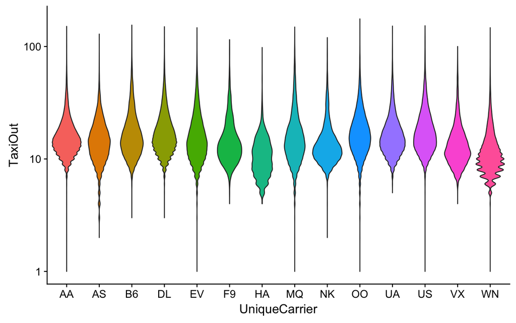

Um plot alternativo que combina a forma de boxplots com a informação de histogramas de densidade *em pé*.

```r
vio <- ontime %>% mutate(group = reorder(UniqueCarrier, TaxiOut, median)) %>%
  ggplot(aes(y = TaxiOut, x = UniqueCarrier, fill = UniqueCarrier)) +
  scale_y_log10() +
  theme(legend.position = "none")
vio + geom_violin()
```

Uma possibilidade é colocar boxplots (sem valores extremos para não poluir a figura) dentro do violin plot para facilitar encontrar a mediana e quartis:

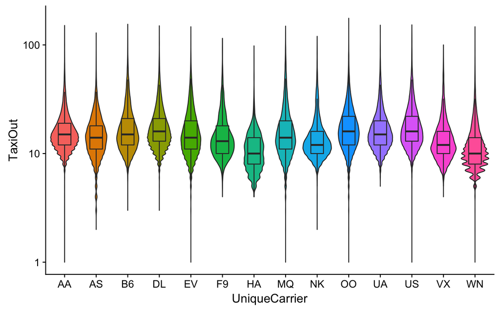

Há quem goste de colocar um boxplot dentro do violin plot para conseguir visualizar os quartis.

```r
vio + geom_violin() + geom_boxplot(width=0.4, outlier.alpha = 0)
```

# Boxplots

Os boxplots deixam de ser úteis quando o volume de dados aumenta (Hofmann et al. 2017), pois o que eles consideram valores extremos (outliers) aumenta linearmente com o tamanho amostral (Figura @ref(fig:boxplot)). E é por isso que no violin plot nós removemos os *outliers* do gráfico. Ainda sim é um dos gráficos mais utilizados para se observar distribuição dos dados (veja [aqui](http://had.co.nz/stat645/project-03/boxplots.pdf) sobre 40 anos de história do boxplot).

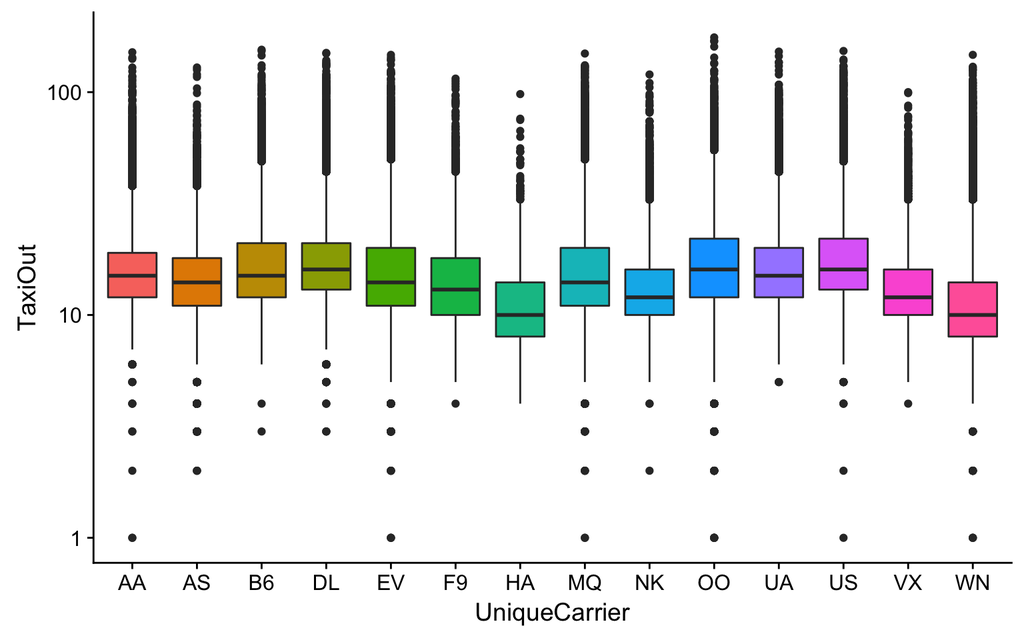

Um boxplot para muitos dados fica poluído com tantos outliers.

```r
ontime %>% mutate(group = reorder(UniqueCarrier, TaxiOut, median)) %>%
  ggplot(aes(y = TaxiOut, x = UniqueCarrier, fill = UniqueCarrier)) +
  scale_y_log10() +
  theme(legend.position = "none") +
  geom_boxplot()
```

# Alternativa 3: letter-value plot

Uma recém criada alternativa aos boxplots convencionais, são os *letter-value plots* (veja Hofmann et al. 2017), que estão disponíveis no pacote `lvplot`. Este plot é baseado na estimativa de quantis (outros que não o primeiro e terceiro como no boxplot). Entretanto, as estimativas somente são confiáveis se há bastante dados!

Abaixo alguns exemplos de uso dos *lvplots*, com algumas opções para a largura das caixas:

1. `linear`: torna a largura de cada caixa inversamente proporcional ao quantil (letter-value) que ela representa, ou seja, começando com os quartis, cada caixa subsequente será um passo mais fina do que a anterior.
2. `area`: torna a *área* de cada caixa proporcional ao número de observações nela.
3. `height`: torna a *largura* de cada caixa proporcional ao número de pontos nela.

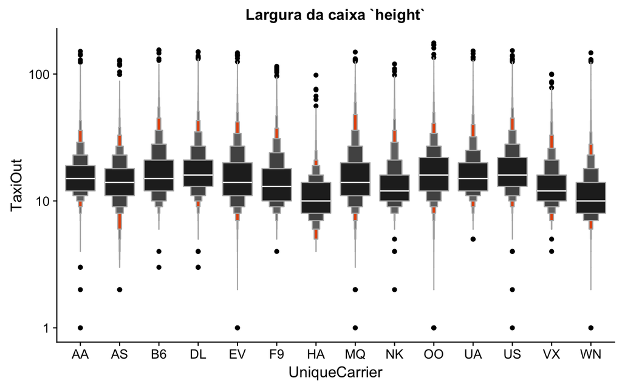

Um exemplo de lvplot com largura da caixa height.

```r
library(lvplot)
library(patchwork) # para fazer painel com vários plots
lv <- ontime %>% mutate(group = reorder(UniqueCarrier, TaxiOut, median)) %>%
  ggplot(aes(y = TaxiOut, x = UniqueCarrier)) +
  scale_y_log10() +
  theme(legend.position = "none")

lv + geom_lv(aes(fill=..LV..), width.method = "height") +
  scale_fill_lv() + ggtitle("Largura da caixa `height`")
```

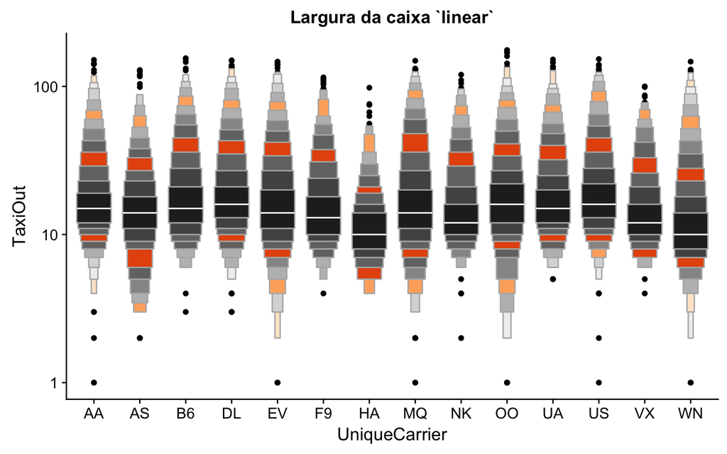

Um lvplot com largura da caixa linear.

```r
lv + geom_lv(aes(fill=..LV..), width.method = "linear") +
  scale_fill_lv() + ggtitle("Largura da caixa `linear`")
```

Eu particularmente acho o gráfico com largura `height` o mais bonito[^3]!

Compare a diferença no número de valores extremos encontrados no boxplot comum e no lvplot!

# Referências

Hofmann, H., Wickham, H., Kafadar, K., 2017. Letter-Value Plots: Boxplots for Large Data. Journal of Computational and Graphical Statistics 26, 469–477. https://doi.org/10.1080/10618600.2017.1305277 [link alternativo](http://vita.had.co.nz/papers/letter-value-plot.html)

[^1]: O tempo de Taxi-out é definido como o tempo gasto por um vôo entre o tempo de desligamento real (AOBT) e o tempo de descolagem real (ATOT). Variável numérica do tempo de táxi em minutos.
[^2]: como as medianas são bem parecidas, o efeito não fica tão legal quanto poderia…
[^3]: Apesar de ainda achar as cores padrão não tão bonitas, mas com umas linhas a mais de código resolvemos esse problema.

Melina de Souza Leite http://melinaleite.weebly.com/

07 de Fevereiro de 2018